# 2020 Election Analysis using Twitter

Brian Roepke

October 25, 2020

# Project Description

Demonstrate how to access Twitter data using rtweet package. Follow instructions for each section and include text annotation/ interpretation of results! What can be concluded based on the data investigation?

https://cran.r-project.org/web/packages/rtweet/vignettes/intro.html

```r
# twitter library
library(rtweet)

# plotting and pipes - tidyverse
library(ggplot2)
library(dplyr, warn.conflicts = FALSE)
options(dplyr.summarise.inform = FALSE) # Suppress summarise info

# text mining library
suppressPackageStartupMessages(library(tidyverse)) # suppress startup message

# date/time libaray
library(lubridate, warn.conflicts = FALSE)
```

```r
get_token()
```

```
## <Token>
## <oauth_endpoint>
##  request:   https://api.twitter.com/oauth/request_token
##  authorize: https://api.twitter.com/oauth/authenticate
##  access:    https://api.twitter.com/oauth/access_token
## <oauth_app> Data104
##   key:    lfrCxMQkaeS6eg88o7Dnx96Uj
##   secret: <hidden>
## <credentials> oauth_token, oauth_token_secret
## ---
```

## Retrieve most recent 3200 timelines of Trump and Biden

- use: ‘JoeBiden’ and ‘realDonaldTrump’
- don’t exclude anything
- save to csv file, so you don’t have to call the api subsequently, in case of long delays
- read the csv file into a dataframe and use that df for subsequent analysis.
  - You will notice using the View (df) function that the the object structure of the original dataframe after the AP call is different from the one you read in. The original has embedded list objects, whereas the one read in is flattend. Also the date/time fields such as ‘create_at’ is char rather than Twitter’s POSIX time format. Use lubridate datetime functions (eg: as_datetime) to convert. Show the column names

```r
## tmls <- get_timelines(c("JoeBiden", "realDonaldTrump"), n = 3200)
## write_as_csv(tmls, "tweets.csv")
```

```r
timelinesdf <- read_twitter_csv("tweets.csv")
```

```r
# Convert the date field to a datetime
timelinesdf$created_at <- as_datetime(timelinesdf$created_at)

#Changed some fields to factors for easier manipulation later
timelinesdf$status_id <- as.factor(timelinesdf$status_id)
timelinesdf$screen_name <- as.factor(timelinesdf$screen_name)

# Fix up the reply count field.  It should be a int and NAs set to 0
timelinesdf$reply_count[is.na(timelinesdf$reply_count)] <- 0
timelinesdf$reply_count <- as.integer(timelinesdf$reply_count)
```

```r
names(timelinesdf)
```

```
##  [1] "user_id"                 "status_id"
##  [3] "created_at"              "screen_name"
##  [5] "text"                    "source"
##  [7] "display_text_width"      "reply_to_status_id"
##  [9] "reply_to_user_id"        "reply_to_screen_name"
## [11] "is_quote"                "is_retweet"
## [13] "favorite_count"          "retweet_count"
## [15] "quote_count"             "reply_count"
## [17] "hashtags"                "symbols"
## [19] "urls_url"                "urls_t.co"
## [21] "urls_expanded_url"       "media_url"
## [23] "media_t.co"              "media_expanded_url"
## [25] "media_type"              "ext_media_url"
## [27] "ext_media_t.co"          "ext_media_expanded_url"
## [29] "ext_media_type"          "mentions_user_id"
```

[output cut: 30 more lines]

## Number of Observations for Each Candidate

```r
summary(timelinesdf$screen_name)
```

```
##        JoeBiden realDonaldTrump
##            3200            3178
```

## Show the top and bottom (select by fields shown) and show a summary of ‘created_at’

```r
top_and_bottom <- timelinesdf %>%
  select(created_at, screen_name, text)

head(top_and_bottom)
```

```
## # A tibble: 6 x 3
##   created_at          screen_name text
##   <dttm>              <fct>       <chr>
## 1 2020-10-18 15:08:00 JoeBiden    "Turns out Twitter isn’t so bad when you read…
## 2 2020-10-18 14:20:00 JoeBiden    "I often think about what it takes for a Blac…
## 3 2020-10-18 00:30:00 JoeBiden    "A job is about a lot more than a paycheck.\n…
## 4 2020-10-17 23:15:00 JoeBiden    "Every day we're reminded just how much is at…
## 5 2020-10-17 22:15:00 JoeBiden    "In the middle of a pandemic, President Trump…
## 6 2020-10-17 21:15:00 JoeBiden    "If we do our part, if we stand together, if …
```

```r
tail(top_and_bottom)
```

```
## # A tibble: 6 x 3
##   created_at          screen_name    text
##   <dttm>              <fct>          <chr>
## 1 2020-08-02 01:49:28 realDonaldTru… "The Democrats are holding back the $1,200…
## 2 2020-08-02 01:49:00 realDonaldTru… "I am thrilled to be back in my home state…
## 3 2020-08-02 01:48:32 realDonaldTru… "I’m with you all the way, thank you!\nhtt…
## 4 2020-08-02 01:48:28 realDonaldTru… "https://t.co/t6R84x4PbP"
## 5 2020-08-02 01:27:50 realDonaldTru… "Congressman Blaine Luetkemeyer (@Luetkeme…
## 6 2020-08-02 01:27:44 realDonaldTru… "Congresswoman Vicky Hartzler (@VickyH4Con…
```

```r
summary(top_and_bottom$created_at)
```

```
##                  Min.               1st Qu.                Median
## "2019-11-09 03:08:00" "2020-05-10 21:03:45" "2020-08-24 13:14:18"
##                  Mean               3rd Qu.                  Max.
## "2020-07-13 11:35:53" "2020-09-22 01:11:42" "2020-10-18 16:02:48"
```

Date range for the `3,200` tweets per user received span from `2019-11-09` to `2020-10-18`

## Create a dataframe that filters on just Biden as follows:

- for timelines past 2020-02-01
- sorted by favorite_count

Show the top 10 observations (by fields shown) and the count/size

```r
df_biden <- timelinesdf %>%
  filter(screen_name == 'JoeBiden' & created_at > '2020-02-01') %>%
  select(created_at, favorite_count, retweet_count, text) %>%
  arrange(desc(favorite_count))

head(df_biden, n = 10L)
```

```
## # A tibble: 10 x 4
##    created_at          favorite_count retweet_count text
##    <dttm>                       <int>         <int> <chr>
##  1 2020-09-30 01:49:00        1894893        318976 Donald Trump is the worst p…
##  2 2020-04-24 18:25:00        1638784        327096 I can’t believe I have to s…
##  3 2020-10-03 18:32:00        1169789        118606 One month until Election Da…
##  4 2020-10-08 02:47:01        1108259         95329 .@KamalaHarris, you made us…
##  5 2020-10-02 12:45:10         965242         67753 Jill and I send our thought…
##  6 2020-10-02 16:22:43         912261        135252 I’m happy to report that Ji…
##  7 2020-10-08 02:33:09         911225        216345 Pitch in $5 to help this ca…
##  8 2020-09-20 01:29:00         870941        235858 I’m Joe Biden and I approve…
##  9 2020-10-02 23:46:00         842912         74934 I’m running as a Democrat, …
## 10 2020-08-11 20:17:32         835494        167866 I have the great honor to a…
```

```r
nrow(df_biden)
```

```
## [1] 2599
```

After filtering out the tweets by date, Biden’s count dropped to `2,599`, vs. the `3,200` pulled down initially.

## Retweets, Replies, and Original Tweets Aggregated over Months for Biden

```r
df_biden_2 <- timelinesdf %>%
  mutate(mon = floor_date(created_at, 'month')) %>%
  mutate(original = is_retweet==FALSE & is_quote==FALSE & is.na(reply_to_status_id)) %>%
  filter(screen_name == 'JoeBiden' & created_at > '2020-02-01') %>%
  group_by(mon) %>%
  summarise(retweet_count = sum(retweet_count),
            replies_count = sum(reply_count),
            orig_count = sum(original))

df_biden_2
```

```
## # A tibble: 9 x 4
##   mon                 retweet_count replies_count orig_count
##   <dttm>                      <int>         <int>      <int>
## 1 2020-02-01 00:00:00        536526             0        239
## 2 2020-03-01 00:00:00       2129821             0        240
## 3 2020-04-01 00:00:00       2446973             0        196
## 4 2020-05-01 00:00:00       2842113             0        200
## 5 2020-06-01 00:00:00       3222991             0        183
## 6 2020-07-01 00:00:00       3209858             0        203
## 7 2020-08-01 00:00:00       5133396             0        302
## 8 2020-09-01 00:00:00       5279618             0        252
## 9 2020-10-01 00:00:00       5475968             0        232
```

```r
summary(df_biden_2)
```

```
##       mon             retweet_count     replies_count   orig_count
##  Min.   :2020-02-01   Min.   : 536526   Min.   :0     Min.   :183.0
##  1st Qu.:2020-04-01   1st Qu.:2446973   1st Qu.:0     1st Qu.:200.0
##  Median :2020-06-01   Median :3209858   Median :0     Median :232.0
##  Mean   :2020-06-01   Mean   :3364140   Mean   :0     Mean   :227.4
##  3rd Qu.:2020-08-01   3rd Qu.:5133396   3rd Qu.:0     3rd Qu.:240.0
##  Max.   :2020-10-01   Max.   :5475968   Max.   :0     Max.   :302.0
```

- **mon**: dates span from the month of Feb through Oct. Note - the dates were only through the middle of October and not a full month. This suggests that activity might increase dramatically for October
- **retweet_count**: A max of 5.5million retweets. A staggering number of monthly retweet totals.
- **replies_count**: This column was empty in the dataset. After investigating the missing data further, this attribute is only available with the premium API twitter access (see URL below).
- **orig_count**: This represents the total number of original Tweets by Biden per month. Reasonably consistent with a mean of `227`.

https://stackoverflow.com/questions/47851662/reply-count-attribute-missing-from-tweet-object

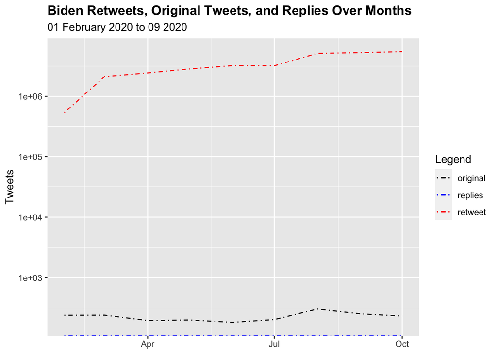

```r
df_biden_2 %>%
  ggplot(aes(x = mon)) +
  geom_line(aes(y = retweet_count , color = "retweet"), linetype="dotdash") +
  geom_line(aes(y = replies_count , color = "replies"), linetype="dotdash") +
  geom_line(aes(y = orig_count , color = "original"), linetype="dotdash") +
  scale_color_manual(name = "Legend",
                       values = c("retweet" = "red",
                                  "replies" = "blue",
                                  "original" = "black")) +
  scale_y_continuous(trans='log10') +
  theme(
    legend.position = "right",
    plot.title = ggplot2::element_text(face = "bold")) +
  ggplot2::labs(
    x = NULL, y = "Tweets",
    title = "Biden Retweets, Original Tweets, and Replies Over Months",
    subtitle = "01 February 2020 to 09 2020"
  )
```

Plotting the three different values on a log scale, you see precisely those observations. The number of total retweets is steadily increasing over time, and Biden’s original tweet activity is reasonably consistent.

## Comparing the Same Activity, but for Trump

```r
df_trump <- timelinesdf %>%
  filter(screen_name == 'realDonaldTrump' & created_at > '2020-02-01') %>%
  select(created_at, favorite_count, retweet_count, text) %>%
  arrange(desc(favorite_count))

df_trump
```

```
## # A tibble: 3,178 x 4
##    created_at          favorite_count retweet_count text
##    <dttm>                       <int>         <int> <chr>
##  1 2020-10-02 04:54:06        1879617        412896 Tonight, @FLOTUS and I test…
##  2 2020-10-03 03:31:34        1222428        140077 Going welI, I think! Thank …
##  3 2020-10-02 22:31:56         761328        131318 https://t.co/B4H105KVSs
##  4 2020-10-03 22:51:58         717269        146377 https://t.co/gvIPuYtTZG
##  5 2020-10-03 17:46:48         651408         93668 OUR GREAT USA WANTS &amp; N…
##  6 2020-10-03 17:19:38         650838        100519 Doctors, Nurses and ALL at …
##  7 2020-10-08 02:57:08         637298         89306 Mike Pence WON BIG!
##  8 2020-10-14 01:50:27         626923        124884 https://t.co/wJN4zv0y8O
##  9 2020-10-06 14:41:06         616856         73896 FEELING GREAT!
## 10 2020-10-04 19:51:14         600563         91104 I really appreciate all of …
## # … with 3,168 more rows
```

```r
nrow(df_trump)
```

```
## [1] 3178
```

## Show and Plot retweets, replies, and original tweets aggregated over months for Trump

```r
df_trump_2 <- timelinesdf %>%
  mutate(mon = floor_date(created_at, 'month')) %>%
  mutate(original = is_retweet==FALSE & is_quote==FALSE & is.na(reply_to_status_id)) %>%
  filter(screen_name == 'realDonaldTrump' & created_at > '2020-02-01') %>%
  group_by(mon) %>%
  summarise(retweet_count = sum(retweet_count),
            replies_count = sum(reply_count),
            orig_count = sum(original))

df_trump_2
```

```
## # A tibble: 3 x 4
##   mon                 retweet_count replies_count orig_count
##   <dttm>                      <int>         <int>      <int>
## 1 2020-08-01 00:00:00      18196219             0        413
## 2 2020-09-01 00:00:00      21267852             0        517
## 3 2020-10-01 00:00:00      17636811             0        309
```

```r
summary(df_trump_2)
```

```
##       mon                      retweet_count      replies_count   orig_count
##  Min.   :2020-08-01 00:00:00   Min.   :17636811   Min.   :0     Min.   :309
##  1st Qu.:2020-08-16 12:00:00   1st Qu.:17916515   1st Qu.:0     1st Qu.:361
##  Median :2020-09-01 00:00:00   Median :18196219   Median :0     Median :413
##  Mean   :2020-08-31 16:00:00   Mean   :19033627   Mean   :0     Mean   :413
##  3rd Qu.:2020-09-16 00:00:00   3rd Qu.:19732036   3rd Qu.:0     3rd Qu.:465
##  Max.   :2020-10-01 00:00:00   Max.   :21267852   Max.   :0     Max.   :517
```

- **mon**: The dates for Trump are a smaller window regardless of the filter because the API reached the max of `3,200` in `August.`
- **retweet_count**: A max of `21 million` retweets. A (`even more`) staggering number of monthly retweet totals.
- **replies_count**: This column was empty in the dataset. After investigating the missing data further, this attribute is only available with the premium API Twitter access.
- **orig_count**: This represents the total number of original Tweets by Trump per month. While Biden’s mean was `227`, Trump’s activity was `413` for the window collected.

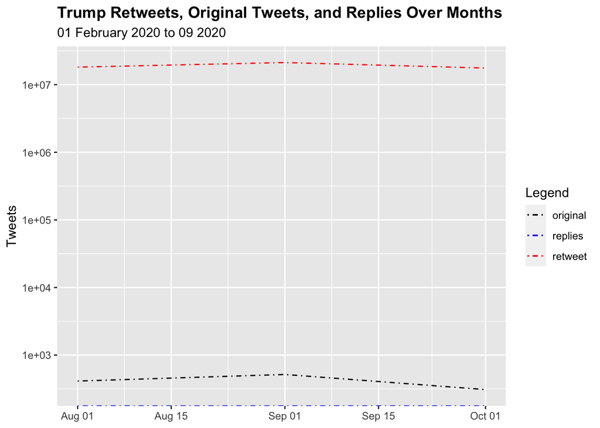

```r
df_trump_2 %>%
  ggplot(aes(x = mon)) +
  geom_line(aes(y = retweet_count , color = "retweet"), linetype="dotdash") +
  geom_line(aes(y = replies_count , color = "replies"), linetype="dotdash") +
  geom_line(aes(y = orig_count , color = "original"), linetype="dotdash") +
  scale_color_manual(name = "Legend",
                       values = c("retweet" = "red",
                                  "replies" = "blue",
                                  "original" = "black")) +
  scale_y_continuous(trans='log10') +
  theme(
    legend.position = "right",
    plot.title = ggplot2::element_text(face = "bold")) +
  ggplot2::labs(
    x = NULL, y = "Tweets",
    title = "Trump Retweets, Original Tweets, and Replies Over Months",
    subtitle = "01 February 2020 to 09 2020"
  )
```

We see a much smoother line for the retweets over the shorter period—a more consistent set of values during this time. Original tweets peeked about September 1st and tapered to October. But note that this is (1) not a full month, and (2) there are only three data points (months) plotted here.

## Plot the frequency of tweets for each user

### by days

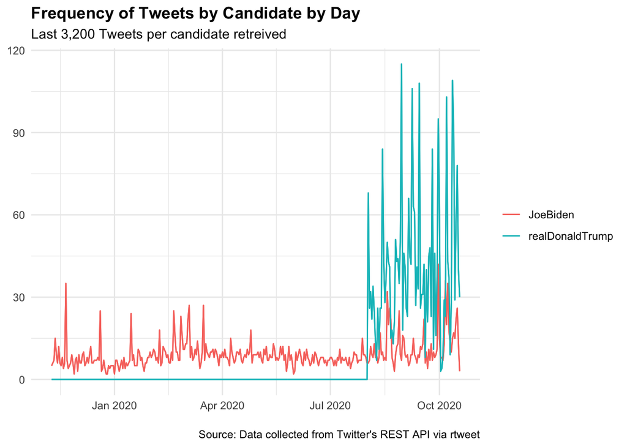

```r
## plot the frequency of tweets for each user over time
timelinesdf %>%
  dplyr::group_by(screen_name) %>%
  ts_plot("days", trim = 0L) +
  ggplot2::geom_line() +
  ggplot2::theme_minimal() +
  ggplot2::theme(
    legend.title = ggplot2::element_blank(),
    legend.position = "right",
    plot.title = ggplot2::element_text(face = "bold")) +
  ggplot2::labs(
    x = NULL, y = NULL,
    title = "Frequency of Tweets by Candidate by Day",
    subtitle = "Last 3,200 Tweets per candidate retreived",
    caption = "\nSource: Data collected from Twitter's REST API via rtweet"
  )
```

This plot visualizes the point that was made above with the compressed window of time. Trump’s tweet volume hit the `3,200` tweet limit in August, whereas Biden overall has had much less activity, and therefore we see a more extended timeline.

### by weeks

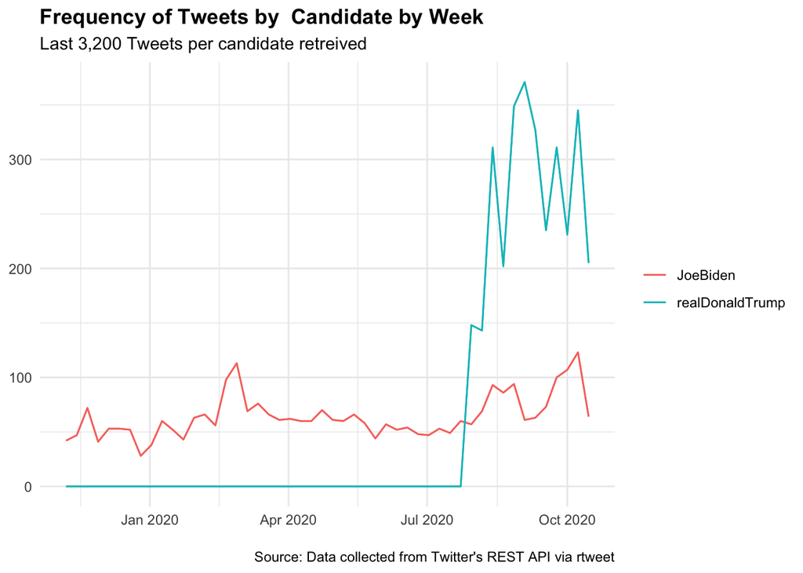

```r
## plot the frequency of tweets for each user over time
timelinesdf %>%
  dplyr::group_by(screen_name) %>%
  ts_plot("weeks", trim = 0L) +
  ggplot2::geom_line() +
  ggplot2::theme_minimal() +
  ggplot2::theme(
    legend.title = ggplot2::element_blank(),
    legend.position = "right",
    plot.title = ggplot2::element_text(face = "bold")) +
  ggplot2::labs(
    x = NULL, y = NULL,
    title = "Frequency of Tweets by  Candidate by Week",
    subtitle = "Last 3,200 Tweets per candidate retreived",
    caption = "\nSource: Data collected from Twitter's REST API via rtweet"
  )
```

When viewing the same data aggregated by Week, we can see a little bit of the noise taken out. Trump was consistently tweeting weekly more than Biden.

### By Month (Adding Tweets vs. Retweets)

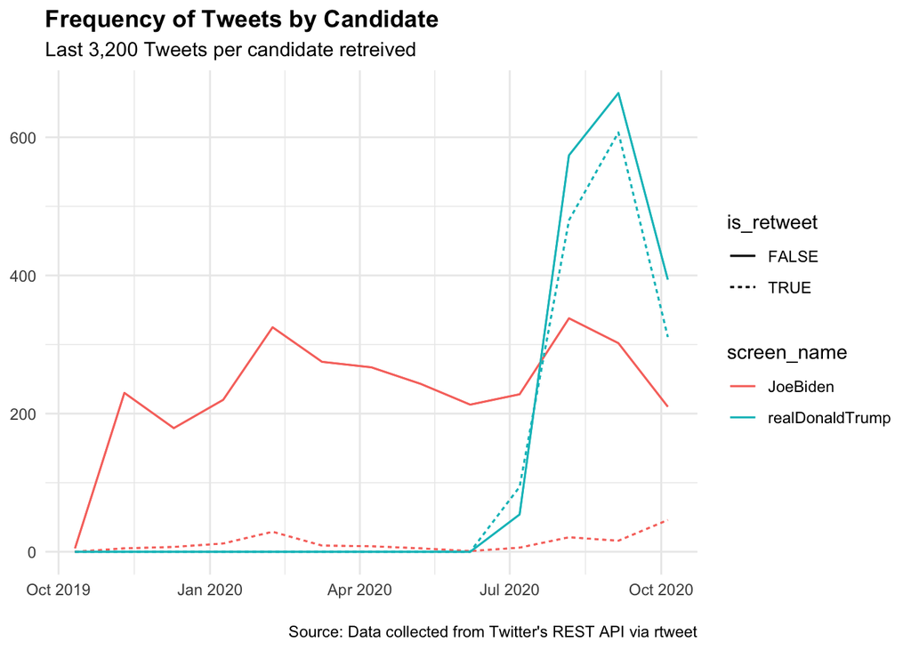

```r
## plot the frequency of tweets for each user over time
timelinesdf %>%
  dplyr::group_by(screen_name, is_retweet) %>%
  ts_plot("month", trim = 0L) +
  ggplot2::geom_line() +
  ggplot2::theme_minimal() +
  ggplot2::theme(
    legend.position = "right",
    plot.title = ggplot2::element_text(face = "bold")) +
  ggplot2::labs(
    x = NULL, y = NULL,
    title = "Frequency of Tweets by Candidate",
    subtitle = "Last 3,200 Tweets per candidate retreived",
    caption = "\nSource: Data collected from Twitter's REST API via rtweet"
  )
```

This graph shows the data aggregated by Month, with the addition/differentiation of showing the tweets (*solid line*) vs. retweets (*dashed line*). This shows how Trump is a much more active retweeter vs. Biden, by a significant margin.

## Get number of followers for Biden and Trump

```r
lu_users <- lookup_users(c("JoeBiden", "realDonaldTrump"))

lu_users %>%
  select(screen_name, followers_count)
```

```
## # A tibble: 2 x 2
##   screen_name     followers_count
##   <chr>                     <int>
## 1 JoeBiden               11339344
## 2 realDonaldTrump        87319816
```

Trump’s followers are `87 million` vs. Biden’s `11 million`. Followers in social media signify how much reach someone has; however, Twitter is an open platform, so reach/read doesn’t equate to how many people are exposed to the content.

## Search 5000 tweets with

- the hashtag #2020Election
- exclude retweets
- save tweets to csv file

```r
# election_hastag <- search_tweets("#2020Election", n = 5000, include_rts = FALSE)
# write_as_csv(election_hastag, "hashtag.csv")
```

```r
election_hastag <- read_twitter_csv("hashtag.csv")
```

```r
# Convert the date field to a datetime
election_hastag$created_at <- as_datetime(election_hastag$created_at)

#Changed some fields to factors for easier manipulation later
election_hastag$status_id <- as.factor(election_hastag$status_id)
election_hastag$screen_name <- as.factor(election_hastag$screen_name)
election_hastag$location <- as.factor(election_hastag$location)
election_hastag$urls_expanded_url <- as.factor(election_hastag$urls_expanded_url)

# Fix up the reply count field.  It should be a int and NAs set to 0
election_hastag$reply_count[is.na(election_hastag$reply_count)] <- 0
election_hastag$reply_count <- as.integer(election_hastag$reply_count)
```

## Show summary of creation date

```r
summary(election_hastag$created_at)
```

```
##                  Min.               1st Qu.                Median
## "2020-10-16 19:31:01" "2020-10-17 16:03:58" "2020-10-18 07:40:42"
##                  Mean               3rd Qu.                  Max.
## "2020-10-18 09:10:15" "2020-10-19 04:10:48" "2020-10-19 20:38:18"
```

## Plot hourly timeline of tweets

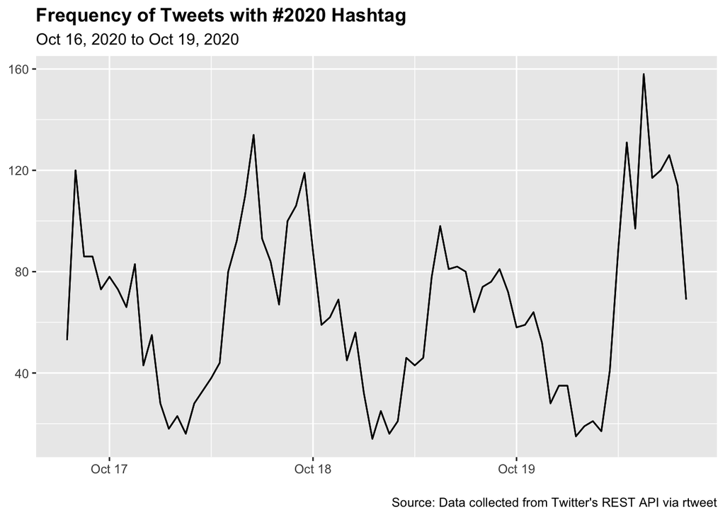

```r
election_hastag %>%
  ts_plot("hours", trim = 0L) +
  ggplot2::geom_line() +
  ggplot2::theme(
    plot.title = ggplot2::element_text(face = "bold")) +
  ggplot2::labs(
    x = NULL, y = NULL,
    title = "Frequency of Tweets with #2020 Hashtag",
    subtitle = "Oct 16, 2020 to Oct 19, 2020",
    caption = "\nSource: Data collected from Twitter's REST API via rtweet"
  )
```

This time series is plotting `5,000` tweets on an hourly basis. The X-axis scale shows the daily spacing, and the peaks and valleys of the data show a frequency of activity increasing around 8:00 am Eastern Time and then maintaining a push through 8:00 pm eastern. The final day of activity does have a slightly higher peak.

This consistency probably suggests that most of these tweets are from the same region of the world. If they were global, we wouldn’t see the consistent up and down pattern we see here. Most likely, the traffic is US based, and we can explore this next.

**Note**: *Twitter returns time in UTC format. Therefore UTC 12:00 pm will be 8:00 am eastern time.* https://developer.twitter.com/en/docs/twitter-ads-api/timezones

```r
# Clean up some of the obvious data discrepancies.  This is an impossible task to fully clean up, but for the purpose of the "top 10" results we can make it more accurate.
election_hastag$location[election_hastag$location == "Washington, DC"] <- "Washington D.C."
election_hastag$location[election_hastag$location == "Washington, D.C."] <- "Washington D.C."
election_hastag$location[election_hastag$location == "United States of America"] <- "USA"
election_hastag$location[election_hastag$location == "United States"] <- "USA"
election_hastag$location[election_hastag$location == "California"] <- "California, USA"
election_hastag$location[election_hastag$location == "Texas"] <- "Texas, USA"
```

```r
loc <- election_hastag %>%
  select(location) %>%
  group_by(location) %>%
  drop_na() %>%
  tally(sort = TRUE, name = "count") %>%
  head(n = 15L)
```

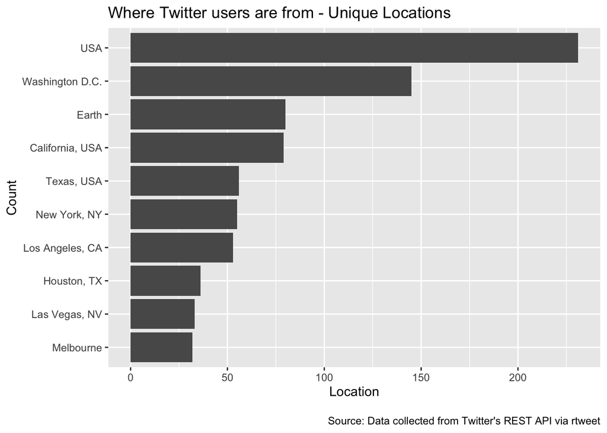

```r
loc[1:10,] %>%
  ggplot() +
  geom_col(aes(x = reorder(location, count), y = count)) +
  coord_flip() +
  ggplot2::labs(
    x = "Count",
    y = "Location",
    title = "Where Twitter users are from - Unique Locations",
    caption = "\nSource: Data collected from Twitter's REST API via rtweet"
  )
```

## Show top 10 most frequently shared link (urls_expanded_url)

```r
election_hastag %>%
  count(urls_expanded_url, sort = TRUE) %>%
  drop_na() %>%
  head(n = 10L)
```

```
## # A tibble: 10 x 2
##    urls_expanded_url                                                           n
##    <fct>                                                                   <int>
##  1 https://bit.ly/32r1TgN#walkaway                                             9
##  2 https://thepalmierireport.com/3rd-debate-moderator-has-deep-ties-to-de…     9
##  3 https://www.gaylonkent.net/                                                 9
##  4 https://is.gd/bpTpKu                                                        7
##  5 https://bit.ly/32r1TgN                                                      6
##  6 https://twitter.com/joebiden/status/1317465638953168899                     6
##  7 https://www.270towin.com/maps/biden-trump-polling-map                       6
##  8 https://www.270towin.com/maps/fivethirtyeight-2020-election-forecast        6
##  9 http://www.vote.org                                                         5
## 10 https://resources.pasenategop.com/votes/                                    5
```

## Show top 3 most retweeted tweet (retweet_count)

```r
election_hastag %>%
  select(created_at, retweet_count, screen_name, text) %>%
  arrange(desc(retweet_count)) %>%
  head(n = 3L)
```

```
## # A tibble: 3 x 4
##   created_at          retweet_count screen_name  text
##   <dttm>                      <int> <fct>        <chr>
## 1 2020-10-17 19:33:49          7854 CBS_Herridge "NEW + READ #2020Election Repu…
## 2 2020-10-17 12:58:21          1076 RobertCahaly "Our new @trafalgar_group #202…
## 3 2020-10-16 21:00:00           532 Varneyco     "With the media actively tryin…
```

## Show top 3 most favorited tweet (hint: favorite_count)

```r
election_hastag %>%
  select(created_at, favorite_count, screen_name, text) %>%
  arrange(desc(favorite_count)) %>%
  head(n = 3L)
```

```
## # A tibble: 3 x 4
##   created_at          favorite_count screen_name  text
##   <dttm>                       <int> <fct>        <chr>
## 1 2020-10-17 19:33:49          13446 CBS_Herridge "NEW + READ #2020Election Rep…
## 2 2020-10-17 12:58:21           3377 RobertCahaly "Our new @trafalgar_group #20…
## 3 2020-10-17 16:04:51           2315 BryanCranst… "Today, I’ll be at the pollin…
```

## Show top 10 tweeters

```r
election_hastag %>%
  count(screen_name, sort = TRUE) %>%
  head(n = 10L)
```

```
## # A tibble: 10 x 2
##    screen_name         n
##    <fct>           <int>
##  1 2020Followers      60
##  2 usaguyme           60
##  3 NancyRe79223741    44
##  4 amadorn            32
##  5 DontBHypocrites    32
##  6 MediaActive        30
##  7 RichJaeger         21
##  8 P_McEnroe          20
##  9 TheWholeN9nes      17
## 10 MakeItPlain        16
```

## What is the top tweeter saying?

```r
# top_tweeter <- get_timelines("usaguyme", n = 100)
# write_as_csv(top_tweeter, "top_tweeter.csv")
```

```r
top_tweeter <- read_twitter_csv("top_tweeter.csv")

# Convert the date field to a datetime
top_tweeter$created_at <- as_datetime(top_tweeter$created_at)

#Changed some fields to factors for easier manipulation later
top_tweeter$screen_name <- as.factor(top_tweeter$screen_name)
```

```r
top_tweeter %>%
  select(created_at, retweet_count, text) %>%
  arrange(desc(retweet_count)) %>%
  head(n = 20L)
```

```
## # A tibble: 20 x 3
##    created_at          retweet_count text
##    <dttm>                      <int> <chr>
##  1 2020-10-18 05:43:26         44871 "The salary of a U.S. Senator is $174,000 …
##  2 2020-10-18 05:40:29         14490 "After corruptly blocking readers from acc…
##  3 2020-10-18 05:14:06             3 "#VOTE for Trump!  We agree, [Socialist] D…
##  4 2020-10-18 06:20:30             2 "#VOTE for Trump!  We agree, [Socialist] D…
##  5 2020-10-18 04:25:18             2 "#BidenFamilyCorruption #BidenHarris2020 \…
##  6 2020-10-20 08:51:55             1 "#VOTE for Trump!  We agree, [Socialist] D…
##  7 2020-10-20 08:31:33             1 "Vote for Trump!  We agree, [Socialist] De…
##  8 2020-10-20 08:28:02             1 "We agree, [Socialist] Democrats are up to…
##  9 2020-10-18 06:21:32             1 "#TRUMP2020ToSaveAmerica  #MAGA #Trump2020…
## 10 2020-10-18 05:50:38             1 "#VOTE for Trump!  We agree, [Socialist] D…
## 11 2020-10-18 05:49:59             1 "#VOTE for Trump!  We agree, [Socialist] D…
## 12 2020-10-18 05:43:37             1 "#VOTE for Trump!  We agree, [Socialist] D…
## 13 2020-10-18 05:15:29             1 "#VOTE for Trump!  We agree, [Socialist] D…
## 14 2020-10-18 05:13:48             1 "#VOTE for Trump!  We agree, [Socialist] D…
## 15 2020-10-18 05:05:25             1 "#VOTE for Trump!  We agree, [Socialist] D…
## 16 2020-10-20 23:09:03             0 "Who do you call? So sad, Support our Poli…
## 17 2020-10-20 08:40:48             0 "Vote for Trump!  We agree, [Socialist] De…
## 18 2020-10-20 08:37:42             0 "#BLM #BlackLivesMatter https://t.co/PsIzu…
## 19 2020-10-20 08:36:42             0 "#BLM #BlackLivesMatter #BlackVoicesForTru…
## 20 2020-10-20 08:22:22             0 "Vote for Trump!  We agree, [Socialist] De…
```

**Note 1**: I selected the second users from the list. The first one was essentially a bot that tweeted out the number of followers each of the candidates had. Not interesting.

What we can see from the list is that two of this user’s recent tweets went "viral: one generating `~45k` retweets and another `~14.5k` retweets. The rest are relatively benign. The text for the two most retweeted tweets are:

- *“The salary of a U.S. Senator is $174,000 per year. This is Joe Biden’s house…. seems legit https://t.co/DtD0DzXlrY”*
- *“After corruptly blocking readers from accessing the New York Post’s expose on Hunter and Joe Biden, Twitter is now throttling circulation of a Fox News story detailing Biden’s business ties in communist China. https://t.co/CIaE1raYHP”*

```r
top_profile <- lookup_users("usaguyme")
create_date <- top_profile$account_created_at
create_date
```

```
## [1] "2008-10-16 02:50:02 UTC"
```

**Note 2**: This user profile, which made it to the top of this hashtag list, was created on October 16th, 2008. I suspected that this might be a bot account, but judging by the fact that the account is 12 years old, it’s probably a human. While this profile only has 129 followers, we can see here, just by picking up the right hashtag, a user can get themselves into the conversation.